# Regressão linear hierárquica bayesiana com amostrador de Gibbs

Modelo de 2 níveis — dado simulado e dado real (`rats.txt`)

Companion literate do `modelo_hierarquico.R`. Mesmo algoritmo (mesma `gibbs_hierarquico()`, mesmo loop) — aqui só junta a matemática com o código e o gráfico. Derivação algébrica completa está em `artigo.pdf`, Seção 3.2; aqui vai o resultado final de cada full conditional.

**Código**

```r
source("gibbs_helpers.R", encoding = "UTF-8")
```

## Modelo

2 níveis: $i=1,\ldots,n$ indivíduos, cada um observado em $j=1,\ldots,T$ instantes de tempo $x_j$.

$$Y_{i,j} \sim N(\alpha_i + \beta_i x_j, \ \tau_c^{-1})$$

Priori hierárquica — $\alpha_i,\beta_i$ (nível do indivíduo) vêm de uma distribuição populacional $\alpha_c,\beta_c$ (nível 2):

$$\begin{aligned}
\alpha_i &\sim N(\alpha_c, \tau_\alpha^{-1}) & \tau_c &\sim \text{Gama}(a_\tau, b_\tau) \\
\beta_i &\sim N(\beta_c, \tau_\beta^{-1}) & \tau_\alpha &\sim \text{Gama}(a_\alpha, b_\alpha) \\
\alpha_c &\sim N(m_\alpha, V_\alpha) & \tau_\beta &\sim \text{Gama}(a_\beta, b_\beta) \\
\beta_c &\sim N(m_\beta, V_\beta)
\end{aligned}$$

7 parâmetros desconhecidos, 7 full conditionals. Todas fecham por conjugação (Normal-Normal pros níveis de média, Normal-Gama pras precisões):

$$\tau_c \mid \cdot \ \sim\ \text{Gama}\left(\frac{nT}{2}+a_\tau,\ \ b_\tau+\frac{1}{2}\sum_{i,j}(y_{i,j}-\alpha_i-\beta_i x_j)^2\right)$$

$$\alpha_i \mid \cdot \ \sim\ N\Big((\tau_c T+\tau_\alpha)^{-1}\big(\tau_c\textstyle\sum_j (y_{i,j}-\beta_i x_j)+\tau_\alpha\alpha_c\big),\ (\tau_c T+\tau_\alpha)^{-1}\Big)$$

$$\beta_i \mid \cdot \ \sim\ N\Big((\tau_c\textstyle\sum_j x_j^2+\tau_\beta)^{-1}\big(\tau_c\textstyle\sum_j (y_{i,j}-\alpha_i) x_j+\tau_\beta\beta_c\big),\ (\tau_c\textstyle\sum_j x_j^2+\tau_\beta)^{-1}\Big)$$

$$\tau_\alpha \mid \cdot \ \sim\ \text{Gama}\left(\frac{n}{2}+a_\alpha,\ \ b_\alpha+\frac{1}{2}\sum_i(\alpha_i-\alpha_c)^2\right), \qquad
\tau_\beta \mid \cdot \ \sim\ \text{Gama}\left(\frac{n}{2}+a_\beta,\ \ b_\beta+\frac{1}{2}\sum_i(\beta_i-\beta_c)^2\right)$$

$$\alpha_c \mid \cdot \ \sim\ N\Big((\tau_\alpha n+\tfrac{1}{V_\alpha})^{-1}\big(\tau_\alpha\textstyle\sum_i\alpha_i+\tfrac{m_\alpha}{V_\alpha}\big),\ (\tau_\alpha n+\tfrac{1}{V_\alpha})^{-1}\Big), \qquad
\beta_c \mid \cdot \ \sim\ N\Big((\tau_\beta n+\tfrac{1}{V_\beta})^{-1}\big(\tau_\beta\textstyle\sum_i\beta_i+\tfrac{m_\beta}{V_\beta}\big),\ (\tau_\beta n+\tfrac{1}{V_\beta})^{-1}\Big)$$

`gibbs_hierarquico()` amostra essas 7 nessa ordem a cada iteração — $\alpha_i, \beta_i$ primeiro (dentro de um loop nos $n$ indivíduos), depois $\tau_c, \tau_\alpha, \tau_\beta, \alpha_c, \beta_c$. Uma função, usada abaixo pro dado simulado e pro `rats.txt`, sem duplicar o loop.

## Dado simulado

30 indivíduos, 5 instantes de tempo, parâmetros populacionais conhecidos ($\alpha_c=20$, $\beta_c=2$) — serve pra checar se o Gibbs recupera os parâmetros usados na simulação.

**Código**

```r
set.seed(22 - 03 - 2018)
```

**Nota**

`22 - 03 - 2018` não é a data 22/03/2018 — R avalia como subtração e vira `set.seed(-1999)`. Bug do autor original tentando usar a data como seed. Mantido de propósito: é o que gera os mesmos dados simulados que já estão no artigo e nas imagens publicadas; corrigir mudaria os números.

**Código**

```r
x        <- c(8, 15, 22, 29, 36)
xbarra   <- mean(x)
x        <- x - xbarra
n        <- 30
t        <- 5
alpha_c  <- 20
beta_c   <- 2
alpha    <- beta <- NULL
taualpha <- 1 / 0.2
taubeta  <- 1 / 0.2
y        <- matrix(NA, n, t)
tau      <- 1
e        <- matrix(rnorm(n * t, 0, sqrt(1 / tau)), n, t)
for (i in 1:n) {
  alpha[i] <- rnorm(1, alpha_c, sqrt(1 / taualpha))
  beta[i]  <- rnorm(1, beta_c, sqrt(1 / taubeta))
  for (j in 1:t) {
    y[i, j] <- alpha[i] + beta[i] * x[j] + e[i, j]
  }
}
```

Priori pouco informativa pros 4 hiperparâmetros de precisão/média populacional ($V_\alpha=V_\beta=10^4$, $a=b=0{,}001$ pras Gamas):

**Código**

```r
m.alpha <- 0; V.alpha <- 1 / 0.0001
m.beta  <- 0; V.beta  <- 1 / 0.0001
a.tau   <- 0.001; b.tau   <- 0.001
a.alpha <- 0.001; b.alpha <- 0.001
a.beta  <- 0.001; b.beta  <- 0.001
nsim    <- 150000
burnin  <- nsim / 2
```

**Código**

```r
set.seed(1)
cadeias_sim <- gibbs_hierarquico(
  y, x, n, t, nsim,
  m.alpha, V.alpha, m.beta, V.beta,
  a.tau, b.tau, a.alpha, b.alpha, a.beta, b.beta
)

inds_sim <- seq(burnin, nsim, 50)
results_sim <- cbind(
  cadeias_sim$alpha.c, cadeias_sim$beta.c, cadeias_sim$tau.c,
  cadeias_sim$tau.alpha, cadeias_sim$tau.beta
) %>% as.data.frame() %>% .[inds_sim, ]

real <- c(alpha_c, beta_c, tau, taualpha, taubeta)
name <- c(expression(alpha[c]), expression(beta[c]), expression(tau[c]), expression(tau[alpha]), expression(tau[beta]))
```

Cadeias dos parâmetros populacionais ($\alpha_c, \beta_c, \tau_c, \tau_\alpha, \tau_\beta$ — não dos 30 $\alpha_i,\beta_i$ individuais, isso vai no caterpillar plot mais abaixo):

**Código**

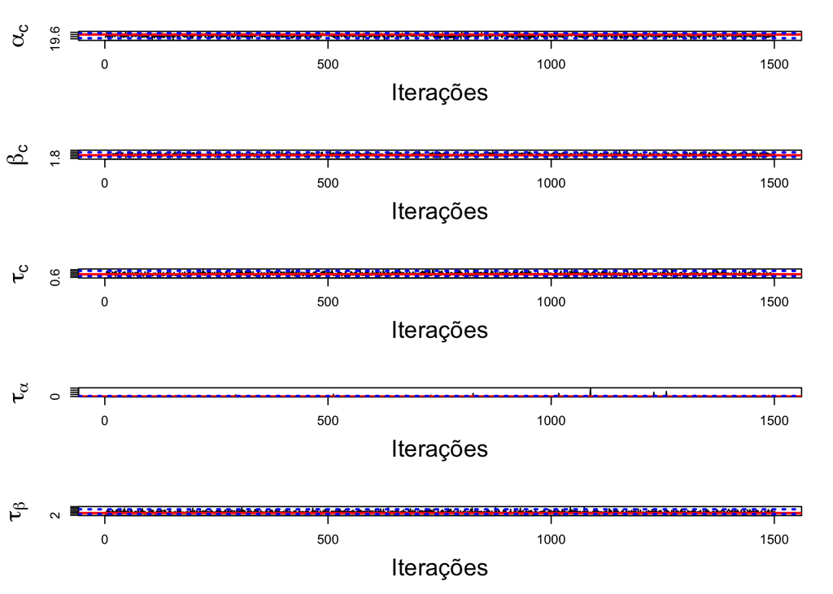

Figura 1: Cadeias dos parâmetros populacionais — dado simulado

```r
cadeia(results_sim, name, real)
```

**Código**

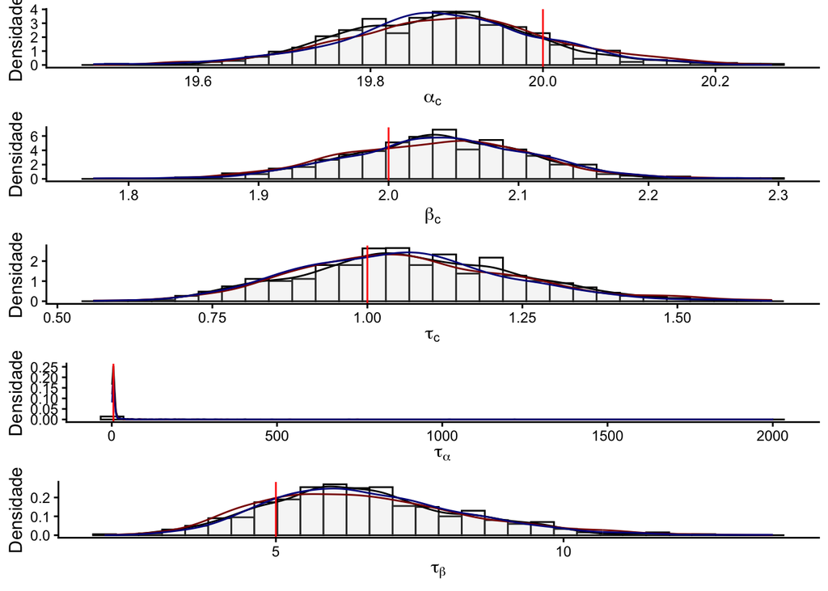

Figura 2: Histograma e densidade — dado simulado

```r
g1 <- hist_den(results_sim[, 1], name = name[1], p = real[1])
g2 <- hist_den(results_sim[, 2], name = name[2], p = real[2])
g3 <- hist_den(results_sim[, 3], name = name[3], p = real[3])
g4 <- hist_den(results_sim[, 4], name = name[4], p = real[4])
g5 <- hist_den(results_sim[, 5], name = name[5], p = real[5])
grid.arrange(g1, g2, g3, g4, g5, ncol = 1)
```

**Código**

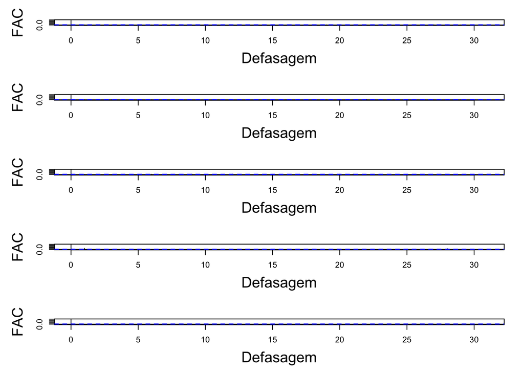

Figura 3: FAC das cadeias — dado simulado

```r
FAC(results_sim)
```

Sumário completo — os 30 $\alpha_i$, os 30 $\beta_i$ e os 5 parâmetros populacionais, contra o valor real usado na simulação:

**Código**

```r
resultado_sim <- coeficientes_hierarquico(
  cadeias_sim$alpha.i[inds_sim, ], alpha,
  cadeias_sim$beta.i[inds_sim, ], beta,
  cadeias_sim$alpha.c, alpha_c,
  cadeias_sim$beta.c, beta_c,
  cadeias_sim$tau.c, tau,
  cadeias_sim$tau.alpha, taualpha,
  cadeias_sim$tau.beta, taubeta,
  ncol(results_sim) + 60
)
tab_sim <- resultado_sim[[2]]
knitr::kable(tab_sim)
```

Tabela 1

|  | 2.5% | Mediana | Média | 97.5% | Param. Pop. | Estimou? |
| --- | --- | --- | --- | --- | --- | --- |
| 1 | 19.198 | 19.8102 | 19.8080 | 20.400 | 19.597 | Sim |
| 2 | 19.281 | 19.8542 | 19.8594 | 20.467 | 19.824 | Sim |
| 3 | 19.459 | 20.0614 | 20.0702 | 20.712 | 19.983 | Sim |
| 4 | 19.547 | 20.0859 | 20.1028 | 20.732 | 20.479 | Sim |
| 5 | 18.878 | 19.5717 | 19.5535 | 20.161 | 19.579 | Sim |
| 6 | 18.829 | 19.5689 | 19.5422 | 20.120 | 19.977 | Sim |
| 7 | 18.914 | 19.5779 | 19.5612 | 20.140 | 19.560 | Sim |
| 8 | 19.189 | 19.8444 | 19.8374 | 20.452 | 20.191 | Sim |
| 9 | 19.215 | 19.8585 | 19.8490 | 20.464 | 19.944 | Sim |
| 10 | 18.971 | 19.6415 | 19.6340 | 20.244 | 19.923 | Sim |
| 11 | 19.569 | 20.1409 | 20.1651 | 20.827 | 20.097 | Sim |
| 12 | 19.355 | 19.9617 | 19.9709 | 20.620 | 20.231 | Sim |
| 13 | 19.258 | 19.8575 | 19.8699 | 20.528 | 19.412 | Sim |
| 14 | 18.930 | 19.5862 | 19.5728 | 20.141 | 19.159 | Sim |
| 15 | 18.700 | 19.4199 | 19.4076 | 20.030 | 18.907 | Sim |
| 16 | 18.356 | 19.1844 | 19.1714 | 19.916 | 19.447 | Sim |
| 17 | 19.239 | 19.8580 | 19.8565 | 20.485 | 19.886 | Sim |
| 18 | 19.153 | 19.7864 | 19.7740 | 20.378 | 20.013 | Sim |
| 19 | 19.703 | 20.2723 | 20.2954 | 21.026 | 20.959 | Sim |
| 20 | 19.372 | 19.9568 | 19.9686 | 20.596 | 19.997 | Sim |
| 21 | 19.607 | 20.2079 | 20.2233 | 20.921 | 20.538 | Sim |
| 22 | 19.480 | 20.0823 | 20.0892 | 20.733 | 20.002 | Sim |
| 23 | 18.969 | 19.6443 | 19.6280 | 20.193 | 19.494 | Sim |
| 24 | 19.763 | 20.3595 | 20.3707 | 21.109 | 19.923 | Sim |
| 25 | 19.011 | 19.6885 | 19.6758 | 20.265 | 19.355 | Sim |
| 26 | 19.852 | 20.5320 | 20.5332 | 21.295 | 20.854 | Sim |
| 27 | 18.972 | 19.6565 | 19.6528 | 20.283 | 19.812 | Sim |
| 28 | 19.337 | 19.9253 | 19.9362 | 20.573 | 20.039 | Sim |
| 29 | 19.585 | 20.1626 | 20.1830 | 20.834 | 20.287 | Sim |
| 30 | 19.782 | 20.4157 | 20.4282 | 21.207 | 20.586 | Sim |
| 31 | 1.441 | 1.5325 | 1.5321 | 1.619 | 1.494 | Sim |
| 32 | 1.671 | 1.7615 | 1.7608 | 1.843 | 1.763 | Sim |
| 33 | 2.417 | 2.4976 | 2.4981 | 2.583 | 2.438 | Sim |
| 34 | 2.297 | 2.3829 | 2.3820 | 2.470 | 2.347 | Sim |
| 35 | 1.923 | 2.0101 | 2.0096 | 2.091 | 1.990 | Sim |
| 36 | 1.767 | 1.8597 | 1.8587 | 1.949 | 1.775 | Sim |
| 37 | 2.087 | 2.1731 | 2.1718 | 2.256 | 2.180 | Sim |
| 38 | 2.261 | 2.3487 | 2.3492 | 2.437 | 2.310 | Sim |
| 39 | 1.706 | 1.7934 | 1.7934 | 1.877 | 1.778 | Sim |
| 40 | 2.375 | 2.4663 | 2.4660 | 2.551 | 2.428 | Sim |
| 41 | 1.876 | 1.9593 | 1.9592 | 2.051 | 1.996 | Sim |
| 42 | 1.239 | 1.3244 | 1.3237 | 1.411 | 1.320 | Sim |
| 43 | 2.326 | 2.4136 | 2.4131 | 2.493 | 2.394 | Sim |
| 44 | 2.049 | 2.1291 | 2.1299 | 2.218 | 2.136 | Sim |
| 45 | 1.563 | 1.6536 | 1.6542 | 1.745 | 1.651 | Sim |
| 46 | 1.907 | 1.9974 | 1.9970 | 2.084 | 2.046 | Sim |
| 47 | 2.448 | 2.5348 | 2.5346 | 2.618 | 2.538 | Sim |
| 48 | 1.801 | 1.8861 | 1.8865 | 1.973 | 1.891 | Sim |
| 49 | 2.739 | 2.8231 | 2.8238 | 2.914 | 2.912 | Sim |
| 50 | 2.401 | 2.4952 | 2.4948 | 2.583 | 2.414 | Sim |
| 51 | 2.348 | 2.4287 | 2.4301 | 2.516 | 2.399 | Sim |
| 52 | 1.552 | 1.6363 | 1.6370 | 1.722 | 1.656 | Sim |
| 53 | 1.502 | 1.5846 | 1.5858 | 1.676 | 1.682 | Sim |
| 54 | 1.883 | 1.9712 | 1.9723 | 2.061 | 1.929 | Sim |
| 55 | 2.086 | 2.1694 | 2.1704 | 2.256 | 2.122 | Sim |
| 56 | 1.221 | 1.3007 | 1.3013 | 1.389 | 1.290 | Sim |
| 57 | 2.003 | 2.0870 | 2.0875 | 2.171 | 2.100 | Sim |
| 58 | 1.468 | 1.5577 | 1.5564 | 1.642 | 1.538 | Sim |
| 59 | 2.098 | 2.1806 | 2.1801 | 2.267 | 2.191 | Sim |
| 60 | 2.152 | 2.2353 | 2.2364 | 2.326 | 2.275 | Sim |
| alpha.c | 19.653 | 19.8852 | 19.8854 | 20.120 | 20.000 | Sim |
| beta.c | 1.892 | 2.0395 | 2.0395 | 2.187 | 2.000 | Sim |
| tau.c | 0.756 | 1.0558 | 1.0631 | 1.414 | 1.000 | Sim |
| tau.alpha | 1.897 | 4.8736 | 16.7916 | 86.144 | 5.000 | Sim |
| tau.beta | 3.617 | 6.4175 | 6.5757 | 10.418 | 5.000 | Sim |

Caterpillar plot: intervalo de credibilidade de cada $\alpha_i$ (ponto branco = média posteriori, ponto azul = $\alpha_i$ real usado na simulação, linha tracejada = $\alpha_c$ populacional):

**Código**

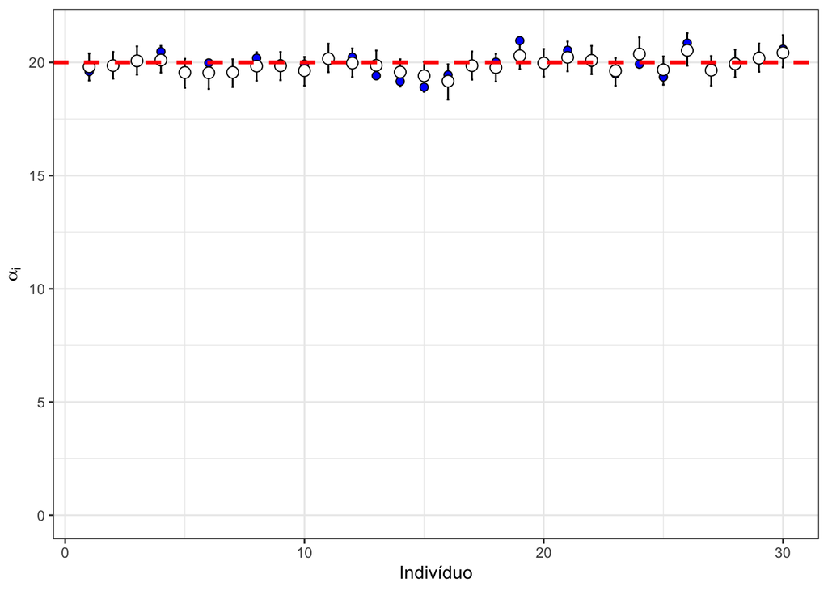

Figura 4: Intervalo de credibilidade de cada alpha_i — dado simulado

```r
cbind(alpha = 1:30, tab_sim[1:30, ]) %>%
  as.data.frame() %>%
  ggplot(aes(x = alpha, y = Média)) +
  geom_errorbar(aes(ymin = `2.5%`, ymax = `97.5%`), colour = "black", width = .1) +
  geom_point(aes(y = `Param. Pop.`), size = 2, shape = 21, fill = "blue") +
  geom_point(size = 3, shape = 21, fill = "white") +
  xlab("Indivíduo") + ylab(expression(alpha[i])) +
  expand_limits(y = 0) +
  theme_bw() +
  geom_hline(yintercept = alpha_c, linetype = "dashed", color = "red", linewidth = 1.1)
```

Mesma leitura pro $\beta_i$:

**Código**

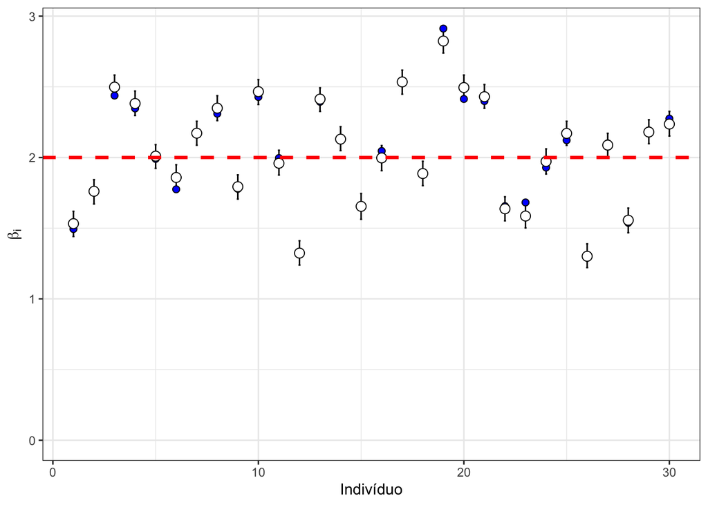

Figura 5: Intervalo de credibilidade de cada beta_i — dado simulado

```r
cbind(beta = 1:30, tab_sim[31:60, ]) %>%
  as.data.frame() %>%
  ggplot(aes(x = beta, y = Média)) +
  geom_errorbar(aes(ymin = `2.5%`, ymax = `97.5%`), colour = "black", width = .1) +
  geom_point(aes(y = `Param. Pop.`), size = 2, shape = 21, fill = "blue") +
  geom_point(size = 3, shape = 21, fill = "white") +
  xlab("Indivíduo") + ylab(expression(beta[i])) +
  expand_limits(y = 0) +
  theme_bw() +
  geom_hline(yintercept = beta_c, linetype = "dashed", color = "red", linewidth = 1.1)
```

## Dado real (`rats.txt`)

Mesma função `gibbs_hierarquico()`, dado real: 30 ratos, peso medido em 5 dias diferentes. Sem parâmetro real pra comparar — aqui o interesse é só o ajuste.

**Código**

```r
rats <- read.table("rats.txt", header = TRUE)

y      <- rats
x      <- c(8, 15, 22, 29, 36)
xbarra <- mean(x)
x      <- x - xbarra
n      <- nrow(y)
t      <- ncol(y)
```

Mesma priori pouco informativa de antes:

**Código**

```r
m.alpha <- 0; V.alpha <- 1 / 0.0001
m.beta  <- 0; V.beta  <- 1 / 0.0001
a.tau   <- 0.001; b.tau   <- 0.001
a.alpha <- 0.001; b.alpha <- 0.001
a.beta  <- 0.001; b.beta  <- 0.001
nsim    <- 50000
burnin  <- nsim / 3
```

**Código**

```r
set.seed(1)
cadeias_rats <- gibbs_hierarquico(
  y, x, n, t, nsim,
  m.alpha, V.alpha, m.beta, V.beta,
  a.tau, b.tau, a.alpha, b.alpha, a.beta, b.beta
)

inds_rats <- seq(burnin, nsim, 50)
results_rats <- cbind(
  cadeias_rats$alpha.c, cadeias_rats$beta.c, cadeias_rats$tau.c,
  cadeias_rats$tau.alpha, cadeias_rats$tau.beta
) %>% as.data.frame() %>% .[inds_rats, ]

name <- c(expression(alpha[c]), expression(beta[c]), expression(tau[c]), expression(tau[alpha]), expression(tau[beta]))
```

**Código**

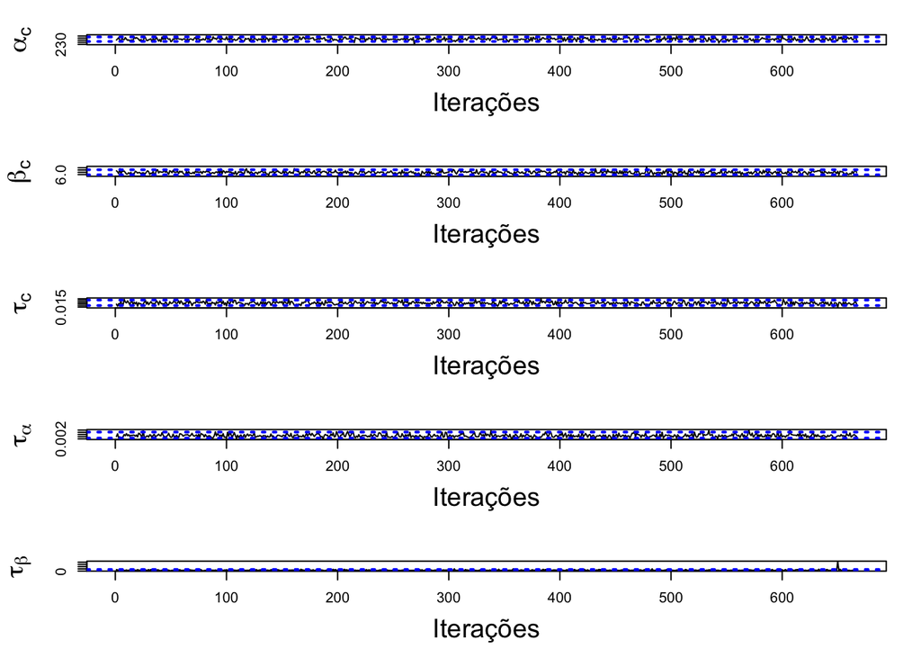

Figura 6: Cadeias dos parâmetros populacionais — rats.txt

```r
cadeia(results_rats, name)
```

**Código**

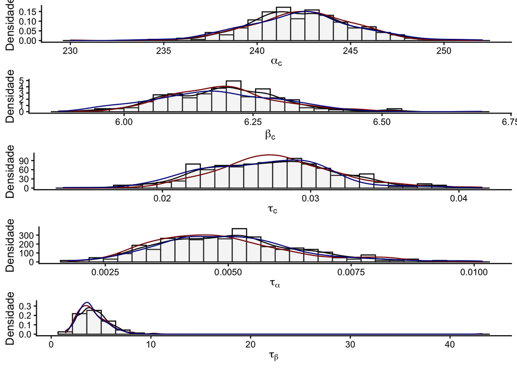

Figura 7: Histograma e densidade — rats.txt

```r
g1 <- hist_den(results_rats[, 1], name = name[1])
g2 <- hist_den(results_rats[, 2], name = name[2])
g3 <- hist_den(results_rats[, 3], name = name[3])
g4 <- hist_den(results_rats[, 4], name = name[4])
g5 <- hist_den(results_rats[, 5], name = name[5])
grid.arrange(g1, g2, g3, g4, g5, ncol = 1)
```

**Código**

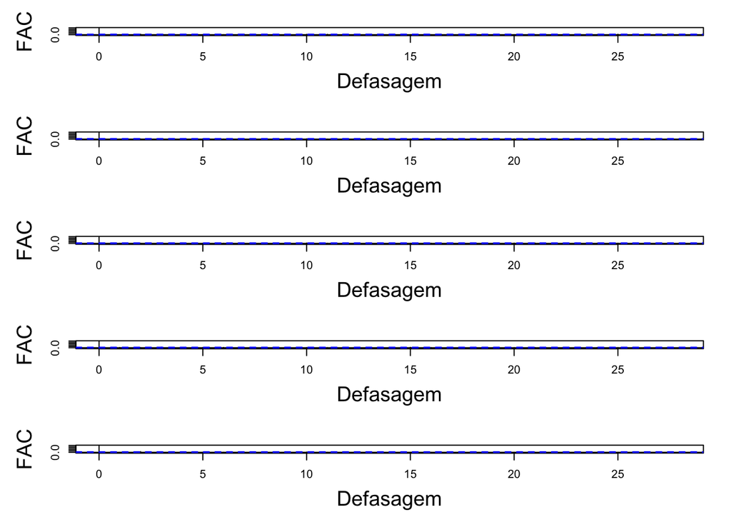

Figura 8: FAC das cadeias — rats.txt

```r
FAC(results_rats)
```

**Código**

```r
resultado_rats <- coeficientes_hierarquico2(
  cadeias_rats$alpha.i[inds_rats, ],
  cadeias_rats$beta.i[inds_rats, ],
  cadeias_rats$alpha.c,
  cadeias_rats$beta.c,
  cadeias_rats$tau.c,
  cadeias_rats$tau.alpha,
  cadeias_rats$tau.beta,
  ncol(results_rats) + 60
)
tab_rats <- resultado_rats[[2]]
knitr::kable(tab_rats)
```

Tabela 2

|  | 2.5% | Média | 97.5% |
| --- | --- | --- | --- |
| 1 | 234.4674 | 239.7711 | 244.8650 |
| 2 | 242.3119 | 247.8024 | 253.1704 |
| 3 | 247.4670 | 252.4651 | 257.5942 |
| 4 | 227.4281 | 232.6673 | 237.9642 |
| 5 | 226.2268 | 231.5398 | 236.6079 |
| 6 | 244.2308 | 249.6326 | 255.2138 |
| 7 | 223.4294 | 228.7150 | 233.7391 |
| 8 | 243.3945 | 248.4276 | 253.8164 |
| 9 | 277.8180 | 283.2207 | 288.7624 |
| 10 | 214.3004 | 219.3117 | 224.5695 |
| 11 | 252.8504 | 258.0388 | 263.0378 |
| 12 | 222.6786 | 228.0055 | 232.6401 |
| 13 | 237.0364 | 242.5554 | 247.8891 |
| 14 | 263.0878 | 268.3323 | 273.5958 |
| 15 | 237.8032 | 242.8896 | 247.4485 |
| 16 | 240.0624 | 245.5494 | 250.4337 |
| 17 | 227.2354 | 232.2828 | 237.3157 |
| 18 | 235.6142 | 240.5535 | 245.8122 |
| 19 | 248.6722 | 253.7973 | 258.9318 |
| 20 | 236.5294 | 241.5602 | 246.7833 |
| 21 | 243.6242 | 248.3927 | 253.3937 |
| 22 | 219.7985 | 225.2131 | 230.5958 |
| 23 | 223.0607 | 228.5912 | 234.2097 |
| 24 | 239.3377 | 245.0348 | 250.6316 |
| 25 | 229.4906 | 234.4759 | 239.5764 |
| 26 | 248.6629 | 253.9677 | 259.0465 |
| 27 | 249.3896 | 254.2848 | 259.5584 |
| 28 | 238.0506 | 242.8673 | 248.1005 |
| 29 | 212.9094 | 217.8503 | 223.1999 |
| 30 | 236.2539 | 241.3516 | 246.4936 |
| 31 | 5.5996 | 6.0616 | 6.5533 |
| 32 | 6.5752 | 7.0440 | 7.5358 |
| 33 | 5.9941 | 6.4621 | 6.9279 |
| 34 | 4.8271 | 5.3444 | 5.8749 |
| 35 | 6.0461 | 6.5750 | 7.0430 |
| 36 | 5.6542 | 6.1851 | 6.6594 |
| 37 | 5.5012 | 5.9842 | 6.4336 |
| 38 | 5.8922 | 6.4134 | 6.8944 |
| 39 | 6.5569 | 7.0483 | 7.5200 |
| 40 | 5.3742 | 5.8489 | 6.3581 |
| 41 | 6.3013 | 6.7891 | 7.2997 |
| 42 | 5.6613 | 6.1185 | 6.5948 |
| 43 | 5.7277 | 6.1617 | 6.6179 |
| 44 | 6.2022 | 6.7072 | 7.1442 |
| 45 | 4.9867 | 5.4223 | 5.8949 |
| 46 | 5.4720 | 5.9265 | 6.4182 |
| 47 | 5.8226 | 6.2764 | 6.7298 |
| 48 | 5.3552 | 5.8496 | 6.3309 |
| 49 | 5.9661 | 6.4094 | 6.8846 |
| 50 | 5.5669 | 6.0664 | 6.5258 |
| 51 | 5.9778 | 6.4144 | 6.9017 |
| 52 | 5.3933 | 5.8554 | 6.3096 |
| 53 | 5.2399 | 5.7518 | 6.2421 |
| 54 | 5.4264 | 5.8991 | 6.4079 |
| 55 | 6.4153 | 6.9005 | 7.3813 |
| 56 | 5.9886 | 6.5421 | 7.0658 |
| 57 | 5.4361 | 5.9019 | 6.3667 |
| 58 | 5.3756 | 5.8357 | 6.3564 |
| 59 | 5.1761 | 5.6755 | 6.1203 |
| 60 | 5.6679 | 6.1335 | 6.5992 |
| alpha.c | 236.9954 | 242.4405 | 247.9075 |
| beta.c | 5.9699 | 6.1860 | 6.4017 |
| tau.c | 0.0199 | 0.0274 | 0.0361 |
| tau.alpha | 0.0027 | 0.0050 | 0.0080 |
| tau.beta | 1.9092 | 4.1085 | 7.7910 |

**Código**

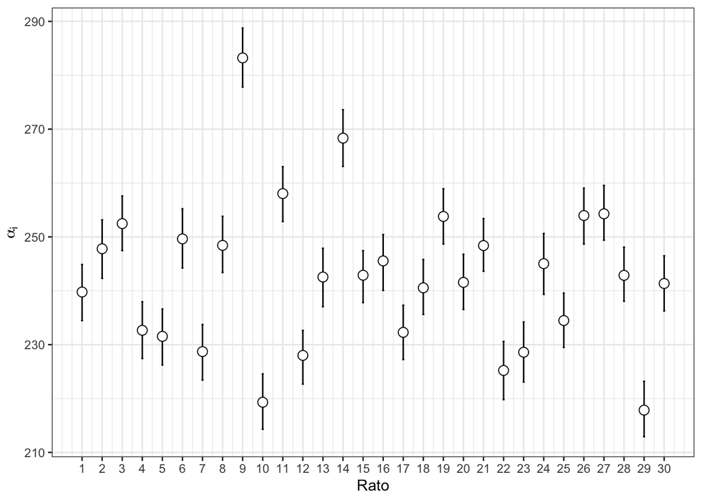

Figura 9: Intervalo de credibilidade de cada alpha_i — rats.txt

```r
cbind(alpha = 1:30, tab_rats[1:30, ]) %>%
  as.data.frame() %>%
  ggplot(aes(x = alpha, y = Média)) +
  geom_errorbar(aes(ymin = `2.5%`, ymax = `97.5%`), colour = "black", width = .1) +
  geom_point(size = 3, shape = 21, fill = "white") +
  xlab("Rato") + ylab(expression(alpha[i])) +
  scale_x_continuous(breaks = seq(1, 30, 1)) +
  theme_bw()
```

**Código**

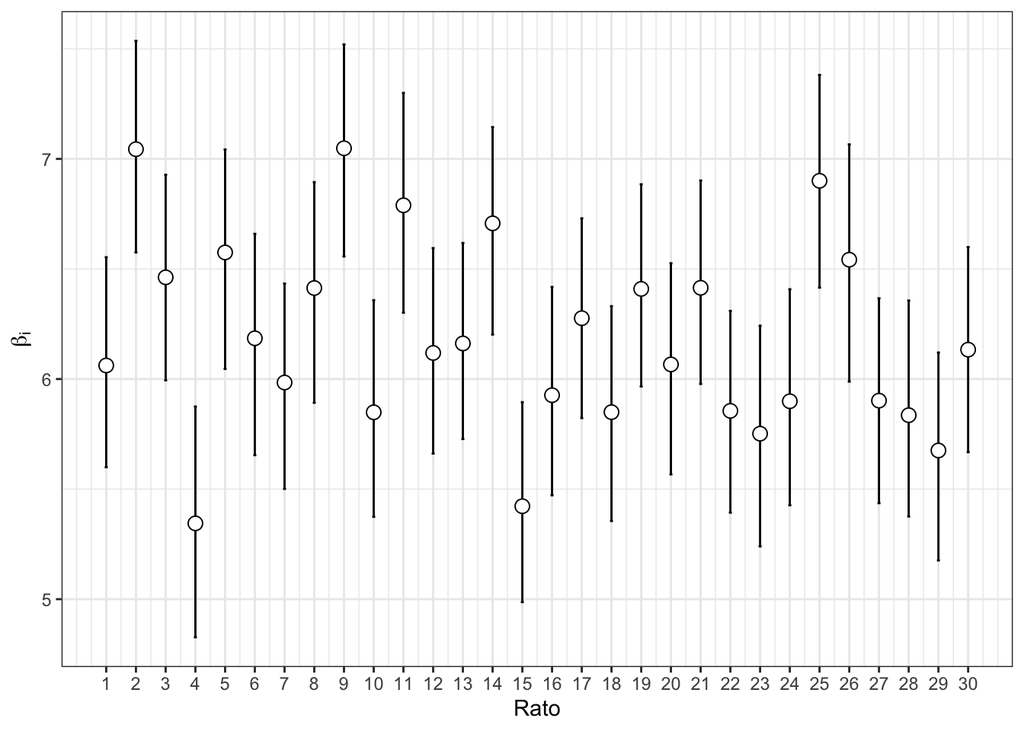

Figura 10: Intervalo de credibilidade de cada beta_i — rats.txt

```r
cbind(beta = 1:30, tab_rats[31:60, ]) %>%
  as.data.frame() %>%
  ggplot(aes(x = beta, y = Média)) +
  geom_errorbar(aes(ymin = `2.5%`, ymax = `97.5%`), colour = "black", width = .1) +
  geom_point(size = 3, shape = 21, fill = "white") +
  xlab("Rato") + ylab(expression(beta[i])) +
  scale_x_continuous(breaks = seq(1, 30, 1)) +
  theme_bw()
```